# Exploratory Data Analysis: Central Bank Independence and Inflation

### 2.2 Binary and Dummy Variables

#### Table 5: Exchange Rate Regime Composition

|  | Fixed (N=492) Mean | Fixed (N=492) Std. Dev. | Floating (N=452) Mean | Floating (N=452) Std. Dev. |
| --- | --- | --- | --- | --- |
| year | 2015.3 | 4.6 | 2015.4 | 4.6 |
| inflation_rate | 6.5 | 5.9 | 3.1 | 3.6 |
| gdp_growth | 3.5 | 4.1 | 3.2 | 7.1 |
| m2_growth | 12.2 | 10.7 | 10.2 | 10.3 |
| unemployment_rate | 6.9 | 5.3 | 7.2 | 6.5 |
| trade_percent_gdp | 79.6 | 43.8 | 77.1 | 34.0 |
| net_lending | -2.7 | 3.1 | -2.5 | 5.6 |
| cbi_extended | 0.7 | 0.1 | 0.7 | 0.1 |
| cbi_gmt | 0.5 | 0.2 | 0.6 | 0.2 |
| discount_rate | 10.9 | 8.6 | 3.3 | 1.8 |
| is_net_exporter | 0.2 | 0.4 | 0.3 | 0.5 |
| oil_price_avg | 75.9 | 22.1 | 75.7 | 22.1 |
| ex_regime | 0.0 | 0.0 | 1.0 | 0.0 |
| crisis_year | 0.3 | 0.4 | 0.2 | 0.4 |
| lag_cbi | 0.7 | 0.1 | 0.7 | 0.1 |
| lag_inflation | 6.2 | 5.5 | 3.1 | 3.6 |
| inflation_clean | 6.5 | 5.9 | 3.1 | 3.6 |
| oil_interaction | 13.3 | 30.7 | 24.3 | 38.5 |
| cbi_x_regime | 0.0 | 0.0 | 0.7 | 0.1 |
| oil_x_crisis | 3.2 | 16.2 | 4.6 | 19.0 |
| log_oil_price | 4.3 | 0.3 | 4.3 | 0.3 |
| log_gdp | 0.0 | 0.0 | 0.0 | 0.1 |

#### Table 6: Net Oil Exporter Composition

|  | Net oil importer (N=3526) Mean | Net oil importer (N=3526) Std. Dev. | Net oil exporter (N=1077) Mean | Net oil exporter (N=1077) Std. Dev. |
| --- | --- | --- | --- | --- |
| year | 2008.0 | 9.9 | 2005.2 | 8.0 |
| inflation_rate | 17.3 | 179.1 | 39.1 | 730.3 |
| gdp_growth | 3.3 | 5.0 | 4.4 | 9.2 |
| m2_growth | 21.0 | 150.0 | 28.0 | 237.5 |
| unemployment_rate | 7.7 | 5.8 | 7.8 | 5.9 |
| trade_percent_gdp | 84.7 | 54.2 | 75.9 | 32.8 |
| net_lending | -2.2 | 4.3 | -1.2 | 11.3 |
| cbi_extended | 0.6 | 0.2 | 0.6 | 0.1 |
| cbi_gmt | 0.5 | 0.3 | 0.5 | 0.2 |
| discount_rate | 15.5 | 78.0 | 12.1 | 18.3 |
| is_net_exporter | 0.0 | 0.0 | 1.0 | 0.0 |
| oil_price_avg | 53.3 | 30.1 | 51.4 | 31.4 |
| ex_regime | 0.4 | 0.5 | 0.6 | 0.5 |
| crisis_year | 0.1 | 0.3 | 0.1 | 0.3 |
| lag_cbi | 0.6 | 0.2 | 0.6 | 0.1 |
| lag_inflation | 17.4 | 181.8 | 40.5 | 743.1 |
| inflation_clean | 7.8 | 14.7 | 9.7 | 17.0 |
| oil_interaction | 0.0 | 0.0 | 51.4 | 31.4 |
| cbi_x_regime | 0.3 | 0.4 | 0.4 | 0.3 |
| oil_x_crisis | 0.0 | 0.0 | 6.7 | 22.4 |
| log_oil_price | 3.8 | 0.7 | 3.7 | 0.7 |
| log_gdp | 0.0 | 0.1 | 0.0 | 0.1 |

This table splits the sample into net oil importers (N=3,526) and exporters (N=1,077), revealing a noticeably skewed composition toward importers. Oil exporters experience substantially higher inflation, inflation volatility, and money growth dispersion, consistent with commodity‑driven macroeconomic cycles. Exporters also display stronger net lending balances, reflecting resource‑related external surpluses. Institutional measures such as central bank independence are comparable across groups, suggesting that observed macro differences are driven by exposure to oil price shocks rather than policy frameworks. The large variance in inflation and money growth among exporters highlights potential heteroskedasticity and non‑linear responses, motivating interaction terms and subgroup robustness checks rather than pooled estimation.

#### Table 7: Crisis Year Decomposition

|  | No crisis (N=4026) Mean | No crisis (N=4026) Std. Dev. | Crisis year (N=577) Mean | Crisis year (N=577) Std. Dev. |
| --- | --- | --- | --- | --- |
| year | 2006.3 | 9.5 | 2014.4 | 6.0 |
| inflation_rate | 24.7 | 413.2 | 6.0 | 9.5 |
| gdp_growth | 3.9 | 6.0 | 1.3 | 7.2 |
| m2_growth | 24.2 | 190.4 | 13.9 | 11.8 |
| unemployment_rate | 7.7 | 5.8 | 7.5 | 5.6 |
| trade_percent_gdp | 82.1 | 49.6 | 85.5 | 52.7 |
| net_lending | -1.8 | 6.4 | -3.6 | 5.2 |
| cbi_extended | 0.6 | 0.2 | 0.7 | 0.2 |
| cbi_gmt | 0.5 | 0.2 | 0.6 | 0.2 |
| discount_rate | 15.6 | 72.8 | 8.1 | 7.7 |
| is_net_exporter | 0.2 | 0.4 | 0.2 | 0.4 |
| oil_price_avg | 50.8 | 31.1 | 67.3 | 20.0 |
| ex_regime | 0.5 | 0.5 | 0.5 | 0.5 |
| crisis_year | 0.0 | 0.0 | 1.0 | 0.0 |
| lag_cbi | 0.6 | 0.2 | 0.7 | 0.2 |
| lag_inflation | 25.3 | 420.7 | 5.8 | 7.2 |
| inflation_clean | 8.6 | 16.1 | 5.9 | 8.2 |
| oil_interaction | 12.0 | 26.1 | 12.5 | 29.5 |
| cbi_x_regime | 0.3 | 0.4 | 0.3 | 0.3 |
| oil_x_crisis | 0.0 | 0.0 | 12.5 | 29.5 |
| log_oil_price | 3.7 | 0.7 | 4.2 | 0.3 |
| log_gdp | 0.0 | 0.1 | 0.0 | 0.1 |

## 3. Distributional Analysis

### 3.1 Inflation Distribution

#### Table 8: Inflation Winsorisation Diagnostics

| Min_raw | Max_raw | Min_clean | Max_clean | Pct_changed |
| --- | --- | --- | --- | --- |
| -16.12 | 23773.13 | -5.00 | 100.00 | 1.87 |

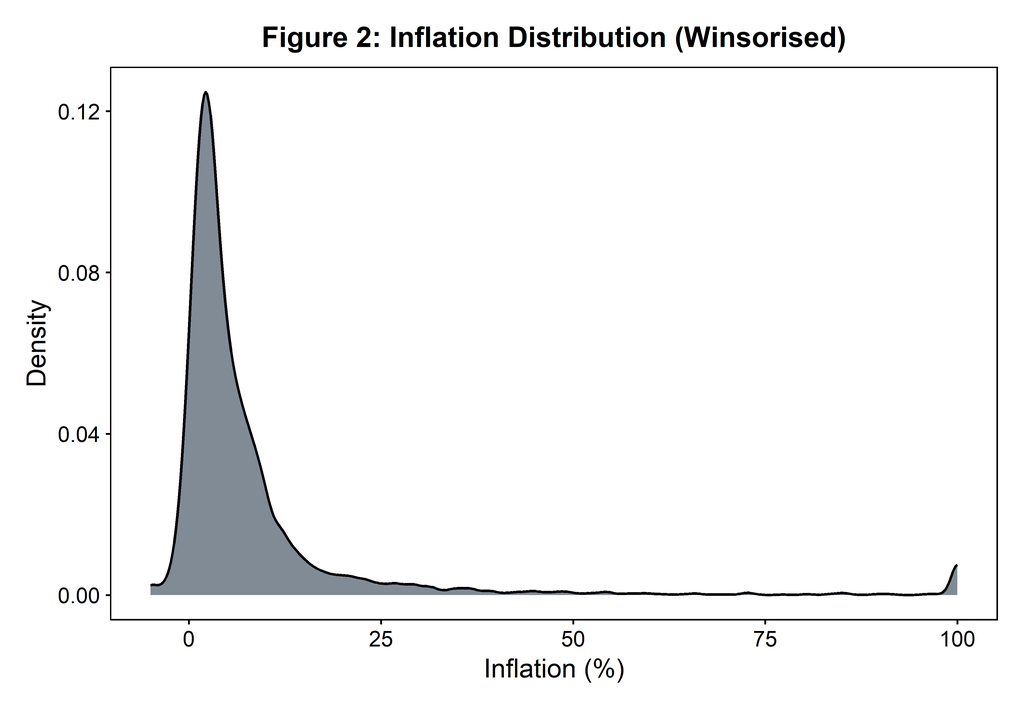